# Assignment 2 - DS4Biz Y63

## TextScraping_Classification

### Team Detail

**Team Name**: sompinandsomshine

### *Student 1*

**Student ID**: 61070278  
**Student Full Name**: นายกิตติภณ สุรุ่งเรืองสกุล

### *Student 2*

**Student ID**: 61070330  
**Student Full Name**: นางสาวอิงฟ้า ภูติวรนาถ

import package ที่ต้องใช้

- requests, bs4 ใช้ scrape ข้อมูลจากหน้าเว็บ
- pandas(pd), numpy(np) ใช้จัดการข้อมูลที่ scrape มาเช่น ทำเป็น DataFrame, แปลงเป็น csv/txt
- warnings ใช้ปิด warning ที่แจ้งเตือน
- CountVectorizer, TfidfTransformer, TfidfVectorizer ใช้เตรียมข้อมูลเช่น ทำ term weighting
- nltk ใช้ในการประมวลผลภาษาธรรมชาติเช่น กำจัด stopwords (คำที่เกิดขึ้นบ่อยและไม่มีอิทธิพลในการจำแนก)
- Pipeline ทำให้การทำงานเป็นลำดับและนำมาใช้กับ GridSearchCV
- train_test_split, cross_val_score, StratifiedKFold, GridSearchCV นำมาทำ model selection และหา best hyperparameter
- neighbors(KNeighborsClassifier), xgboost(xgb), ensemble(RandomForestClassifier) model ที่จะนำมาใช้ในการทำนายว่าแต่ข่าวเป็นประเภทไหน

```python
import requests
import bs4

import pandas as pd
import numpy as np

import warnings
warnings.filterwarnings('ignore')

from sklearn.feature_extraction.text import CountVectorizer
from sklearn.feature_extraction.text import TfidfTransformer
from sklearn.feature_extraction.text import TfidfVectorizer

import nltk
from nltk.corpus import stopwords

from sklearn.model_selection import train_test_split
from sklearn.model_selection import StratifiedKFold
from sklearn.model_selection import GridSearchCV
from sklearn.model_selection import cross_val_score
from sklearn.metrics import accuracy_score

from sklearn.neighbors import KNeighborsClassifier
import xgboost as xgb
from sklearn.ensemble import RandomForestClassifier

import matplotlib.pyplot as plt
```

# Data Collection

link: http://www.it.kmitl.ac.th/~teerapong/news_archive/index.html

ใช้ **requests.get** ตรวจสอบว่าลิงก์ที่ต้องการ scrape ข้อมูลสามารถเข้าได้มั้ย

```python
response = requests.get('http://www.it.kmitl.ac.th/~teerapong/news_archive/index.html') #ใส่ลิงก์ที่เราต้องการ scrape
print(response) # response 200 คือสามารถเข้าถึงได้ พร้อมดึงข้อมูล
```

```
<Response [200]>
```

ใช้ **bs4.BeautifulSoup** ในการอ่าน code ของลิงก์ที่เราใส่ไป

```python
html_page = bs4.BeautifulSoup(response.content, 'html.parser') #เก็บ code ที่ได้ไว้ในตัวแปร html_page
print(html_page)
```

[output not shown]

```python
#ต้องการดึงลิงก์ข่าวของแต่ละเดือน
selector = 'body > div > div.main > ul > li> a' #ลิงก์ข่าวของแต่ละเดือนอยู่ใน tags ul>li>a จึงกำหนดให้ไปดึง code ที่อยู่ในส่วนนั้นออกมา
tags = html_page.select(selector) #โดยให้ return code ที่ตรงกับ selector ที่กำหนดไว้ทั้งหมดและเก็บไว้ในตัวแปร tags
tags #เรียกดูผลลัพธ์ว่าตรงกับที่ต้องการมั้ย
```

```
[<a href="month-jan-2017.html">January</a>,
 <a href="month-feb-2017.html">February</a>,
 <a href="month-mar-2017.html">March</a>,
 <a href="month-apr-2017.html">April</a>,
 <a href="month-may-2017.html">May</a>,
 <a href="month-jun-2017.html">June</a>,
 <a href="month-jul-2017.html">July</a>,
 <a href="month-aug-2017.html">August</a>,
 <a href="month-sep-2017.html">September</a>,
 <a href="month-oct-2017.html">October</a>,
 <a href="month-nov-2017.html">November</a>,
 <a href="month-dec-2017.html">December</a>]
```

ได้ code ที่เป็นลิงก์มาหมดแล้วแต่ยังไม่พร้อมใช้งานเพราะ ลิงก์ที่ต้องการมีหน้าตาแบบนี้ http://www.it.kmitl.ac.th/~teerapong/news_archive/month-jan-2017.html จึงจะทำการสร้าง **list_archive** เพื่อรอเก็บลิงก์ที่พร้อมใช้งาน

```python
list_archive = [] #list ที่รอเก็บลิงก์ที่จะนำไปใช้งานต่อ
for tag in tags: #ทำการวน for loop จากตัวแปร tags ที่เก็บ code ที่มีลิงก์อยู่
    list_archive.append('http://www.it.kmitl.ac.th/~teerapong/news_archive/' + tag['href'])
    '''นำ tag['href'] ซึ่งคือส่วนที่อยู่ใน href เท่านั้น (ex. month-jan-2017.html) มาต่อกับ http://www.it.kmitl.ac.th/~teerapong/news_archive/
    เพื่อให้ได้ลิงก์ตามที่เราต้องการ แล้วลิงก์นั้นไปเก็บไว้ใน list_archive ที่สร้างเอาไว้'''
list_archive #เรียกดูผลลัพธ์ว่าตรงกับที่ต้องการมั้ย
```

```
['http://www.it.kmitl.ac.th/~teerapong/news_archive/month-jan-2017.html',
 'http://www.it.kmitl.ac.th/~teerapong/news_archive/month-feb-2017.html',
 'http://www.it.kmitl.ac.th/~teerapong/news_archive/month-mar-2017.html',
 'http://www.it.kmitl.ac.th/~teerapong/news_archive/month-apr-2017.html',
 'http://www.it.kmitl.ac.th/~teerapong/news_archive/month-may-2017.html',
 'http://www.it.kmitl.ac.th/~teerapong/news_archive/month-jun-2017.html',
 'http://www.it.kmitl.ac.th/~teerapong/news_archive/month-jul-2017.html',
 'http://www.it.kmitl.ac.th/~teerapong/news_archive/month-aug-2017.html',
 'http://www.it.kmitl.ac.th/~teerapong/news_archive/month-sep-2017.html',
 'http://www.it.kmitl.ac.th/~teerapong/news_archive/month-oct-2017.html',
 'http://www.it.kmitl.ac.th/~teerapong/news_archive/month-nov-2017.html',
 'http://www.it.kmitl.ac.th/~teerapong/news_archive/month-dec-2017.html']
```

### Create function

สร้าง Function ที่ใช้ในการ scrape

- category ประเภทข่าว -> extract_category()
- title หัวข้อข่าว -> extract_title()
- link ลิงก์ข่าว -> extract_link_title()

```python
# สร้าง Function ที่ใช้ในการ scrape category
def extract_category(html_page):
    selector = 'body > div > div.main > table > tbody > tr> td.category' #กำหนดให้ดึงค่าที่อยู่ในตารางในส่วนของคอลัมน์  Article Category
    tags = html_page.select(selector)
    category = [] #สร้าง list ชื่อ category ไว้รอเก็บค่าที่ scrape ได้

    for tag in tags: #ทำการวน for loop จากตัวแปร tags
        if tag.text.strip() != 'N/A': #จะเอาข้อมูล category ใส่ใน list ชื่อ category ถ้าข้อมูลที่ดึงมาไม่เป็น N/A (ค่าว่าง)
            category.append(tag.text.strip()) #เพิ่มข้อมูลที่ scrape ได้ใส่ไว้ใน list ชื่อ category

    return category
```

```python
# สร้าง Function ที่ใช้ในการ scrape title
def extract_title(html_page):
    selector = 'body > div > div.main > table > tbody > tr > td.title > a'
    #กำหนดให้ดึงค่าที่อยู่ในตารางในส่วนของคอลัมน์  Article Title และดึงไปที่ tag a เพราะแถวที่มีข้อมูลจะเป็น tag a แต่ถ้าไม่มีข้อมูลแล้วจะเป็น tag i
    tags = html_page.select(selector)
    title = [] #สร้าง list ชื่อ title ไว้รอเก็บค่าที่ scrape ได้

    for tag in tags: #ทำการวน for loop จากตัวแปร tags
        title.append(tag.text.strip()) #เพิ่มข้อมูลที่ scrape ได้ใส่ไว้ใน list ชื่อ title

    return title
```

```python
# สร้าง Function ที่ใช้ในการ scrape link
def extract_link_title(html_page):
    selector = 'body > div > div.main > table > tbody > tr > td.title > a'
    #กำหนดให้ดึงค่าที่อยู่ในตารางในส่วนของคอลัมน์  Article Title และดึงไปที่ tag a เพราะลิงก์ของข่าวอยู่ tag a
    tags = html_page.select(selector)
    link_title = [] #สร้าง list ชื่อ link_title ไว้รอเก็บค่าที่ scrape ได้

    for tag in tags: #ทำการวน for loop จากตัวแปร tags
        link_title.append('http://www.it.kmitl.ac.th/~teerapong/news_archive/' + tag['href'])
        #ทำการแก้ไขข้อมูลให้เป็นลิงก์ที่พร้อมใช้งาน แล้วค่อยเพิ่มข้อมูลใส่ไว้ใน list ชื่อ link_title

    return link_title
```

```python
#ตัวอย่าง
url = 'http://www.it.kmitl.ac.th/~teerapong/news_archive/month-jan-2017.html'
response = requests.get(url)
html_page = bs4.BeautifulSoup(response.content, 'html.parser')
print('example:\n', extract_category(html_page)[0],'\n', extract_title(html_page)[0],'\n', extract_link_title(html_page)[0])
```

```
example:
 technology
 21st-Century Sports: How Digital Technology Is Changing the Face Of The Sporting Industry
 http://www.it.kmitl.ac.th/~teerapong/news_archive/article-jan-0418.html
```

สร้าง Function **extract_news_archive_info()** สำหรับเรียกใช้งาน Function ในการ scrape category ประเภทข่าว, title หัวข้อข่าว, link ลิงก์ข่าว ทั้งหมด โดยใส่แค่ลิงก์เดือนก็จะดึง category ประเภทข่าว, title หัวข้อข่าว, link ลิงก์ข่าว ในเดือนนั้นออกมาทั้งหมด และจะ return กลับมาในรูปของ DataFrame

```python
def extract_news_archive_info(url): #รับลิงก์ของเดือนที่ต้องการดึงข้อมูล
    response = requests.get(url)
    html_page = bs4.BeautifulSoup(response.content, 'html.parser') #ดึงหน้าเว็บของลิงก์นั้น

    #เอาหน้าเว็บที่ดึงออกมาไปใส่ใน argument แต่ละ Function ที่ได้สร้างไว้เพื่อดึงข้อมูล ผลลัพธ์ที่ได้กลับมาจะอยู่ในรูปของ list
    category = extract_category(html_page)
    title = extract_title(html_page)
    link_title = extract_link_title(html_page)

    #เอาข้อมูลที่อยู่ในรูปของ list ที่ได้กลับมามาแปลงให้อยู่ในรูปของ pandas Series เพื่อที่จะได้เอาข้อมูลทั้ง 3 ตัวมา concat กันให้เป็น DataFrame
    category = pd.Series(category)
    title = pd.Series(title)
    link_title = pd.Series(link_title)

    #เอาข้อมูลทั้ง 3 ตัวที่อยู่ในรูปของ pandas Series แล้วมา concat กันในแนวคอลัมน์ (เอาคอลัมน์มาต่อๆกัน)
    result = pd.concat([category, title, link_title], axis=1)
    #rename ชื่อ column ให้ตรงกับที่ต้องการใช้งาน โดยจะเปลี่ยนชื่อเป็น category-ประเภทข่าว, title-หัวข้อข่าว, link-ลิงก์ข่าว
    result = result.rename(columns={0: "category", 1: "title", 2: "link"})
    return result #return DataFrame
```

```python
#ตัวอย่าง อันนี้คือ DataFrame ที่ Function extract_news_archive_info() return กลับมา
#ข้อมูลที่ return กลับมาจะเป็นข่าวทั้งหมดในเดือนที่เราส่งไป
url = 'http://www.it.kmitl.ac.th/~teerapong/news_archive/month-jan-2017.html'
extract_news_archive_info(url)
```

|  | category | title | link |
| --- | --- | --- | --- |
| 0 | technology | 21st-Century Sports: How Digital Technology Is... | http://www.it.kmitl.ac.th/~teerapong/news_arch... |
| 1 | business | Asian quake hits European shares | http://www.it.kmitl.ac.th/~teerapong/news_arch... |
| 2 | technology | BT offers free net phone calls | http://www.it.kmitl.ac.th/~teerapong/news_arch... |
| 3 | business | Barclays shares up on merger talk | http://www.it.kmitl.ac.th/~teerapong/news_arch... |
| 4 | sport | Barkley fit for match in Ireland | http://www.it.kmitl.ac.th/~teerapong/news_arch... |
| ... | ... | ... | ... |
| 113 | business | Worldcom boss 'left books alone' | http://www.it.kmitl.ac.th/~teerapong/news_arch... |
| 114 | technology | Xbox 2 may be unveiled in summer | http://www.it.kmitl.ac.th/~teerapong/news_arch... |
| 115 | technology | Xbox power cable 'fire fear' | http://www.it.kmitl.ac.th/~teerapong/news_arch... |
| 116 | business | Yangtze Electric's profits double | http://www.it.kmitl.ac.th/~teerapong/news_arch... |
| 117 | business | Yukos loses US bankruptcy battle | http://www.it.kmitl.ac.th/~teerapong/news_arch... |

118 rows × 3 columns

### Create DataFrame

สร้าง DataFrame เพื่อรอรับข้อมูลที่ scrape ได้

ซึ่งข้อมูลที่เราจะ scrape คือลิงก์ข่าวในแต่ละเดือนใน list_archive โดยเราจะ scrape category ประเภทข่าว, title หัวข้อข่าว, link ลิงก์ข่าว

```python
#สร้าง DataFrame ที่รอรับข้อมูลที่ scrape ได้และกำหนดชื่อ column ตามสิ่งที่จะ scrape
df = pd.DataFrame(columns=['category', 'title', 'link'])
df #ได้ df เปล่าๆที่รอรับข้อมูลที่ scrape ได้
```

|  | category | title | link |
| --- | --- | --- | --- |

### เอา list_archive (ลิงก์เดือนทั้งหมด) ไปเข้า Function extract_news_archive_info()

ขั้นตอนนี้ทำเพื่อให้ได้ข่าวทั้งหมดในทุกๆเดือนมารวมกันเป็น DataFrame อันเดียว

```python
list_archive
```

```
['http://www.it.kmitl.ac.th/~teerapong/news_archive/month-jan-2017.html',
 'http://www.it.kmitl.ac.th/~teerapong/news_archive/month-feb-2017.html',
 'http://www.it.kmitl.ac.th/~teerapong/news_archive/month-mar-2017.html',
 'http://www.it.kmitl.ac.th/~teerapong/news_archive/month-apr-2017.html',
 'http://www.it.kmitl.ac.th/~teerapong/news_archive/month-may-2017.html',
 'http://www.it.kmitl.ac.th/~teerapong/news_archive/month-jun-2017.html',
 'http://www.it.kmitl.ac.th/~teerapong/news_archive/month-jul-2017.html',
 'http://www.it.kmitl.ac.th/~teerapong/news_archive/month-aug-2017.html',
 'http://www.it.kmitl.ac.th/~teerapong/news_archive/month-sep-2017.html',
 'http://www.it.kmitl.ac.th/~teerapong/news_archive/month-oct-2017.html',
 'http://www.it.kmitl.ac.th/~teerapong/news_archive/month-nov-2017.html',
 'http://www.it.kmitl.ac.th/~teerapong/news_archive/month-dec-2017.html']
```

เอาแต่ละลิงก์ใน list_archive ไปเข้า function extract_news_archive_info() และเพิ่มเข้าไปใน DataFrame ที่เราเตรียมไว้

```python
for url in list_archive: #วน for loop เพื่อเอาลิงก์เดือนทีละอันไปเข้า function
    result = extract_news_archive_info(url) #เอาลิงก์เดือนไปเข้า function และเก็บ DataFrame ที่ return กลับมาในตัวแปร result
    df = df.append(result, ignore_index=True) #เอา result ที่ได้จาก function ไปเพิ่มใน DataFrame ที่สร้างรอไว้
```

```python
df #หน้าตาของ DataFrame ที่มีข้อมูล category ประเภทข่าว, title หัวข้อข่าว, link ลิงก์ข่าว ทั้งหมด
```

|  | category | title | link |
| --- | --- | --- | --- |
| 0 | technology | 21st-Century Sports: How Digital Technology Is... | http://www.it.kmitl.ac.th/~teerapong/news_arch... |
| 1 | business | Asian quake hits European shares | http://www.it.kmitl.ac.th/~teerapong/news_arch... |
| 2 | technology | BT offers free net phone calls | http://www.it.kmitl.ac.th/~teerapong/news_arch... |
| 3 | business | Barclays shares up on merger talk | http://www.it.kmitl.ac.th/~teerapong/news_arch... |
| 4 | sport | Barkley fit for match in Ireland | http://www.it.kmitl.ac.th/~teerapong/news_arch... |
| ... | ... | ... | ... |
| 1403 | sport | Woodward eyes Brennan for Lions | http://www.it.kmitl.ac.th/~teerapong/news_arch... |
| 1404 | business | WorldCom trial starts in New York | http://www.it.kmitl.ac.th/~teerapong/news_arch... |
| 1405 | business | Yukos accused of lying to court | http://www.it.kmitl.ac.th/~teerapong/news_arch... |
| 1406 | business | Yukos drops banks from court bid | http://www.it.kmitl.ac.th/~teerapong/news_arch... |
| 1407 | sport | Zambia confident and cautious | http://www.it.kmitl.ac.th/~teerapong/news_arch... |

1408 rows × 3 columns

ลองเช็คค่า null

```python
df.isna().sum()
#ไม่มีค่า null เพราะ clean ไปตอน scrape ข้อมูลแล้ว
```

```
category    0
title       0
link        0
dtype: int64
```

### Add id coloumn

แต่ละข่าวมี id ของมันเองเลยจะทำการเก็บแยกเพิ่มอีกคอลัมน์

```python
#ในแต่ละลิงก์ข่าวจะมี id ของข่าวแฝงอยู่
df['link'].iloc[0]
```

```
'http://www.it.kmitl.ac.th/~teerapong/news_archive/article-jan-0418.html'
```

```python
#ใช้ index slicing ในการหา id ข่าว โดยจะเริ่มเก็บตั้งแต่ตัวที่ 50 ถึงตัวที่ 6 จากหลังสุด
df['id'] = df['link'].str[50:-5]
df
```

|  | category | title | link | id |
| --- | --- | --- | --- | --- |
| 0 | technology | 21st-Century Sports: How Digital Technology Is... | http://www.it.kmitl.ac.th/~teerapong/news_arch... | article-jan-0418 |
| 1 | business | Asian quake hits European shares | http://www.it.kmitl.ac.th/~teerapong/news_arch... | article-jan-0027 |
| 2 | technology | BT offers free net phone calls | http://www.it.kmitl.ac.th/~teerapong/news_arch... | article-jan-0631 |
| 3 | business | Barclays shares up on merger talk | http://www.it.kmitl.ac.th/~teerapong/news_arch... | article-jan-2105 |
| 4 | sport | Barkley fit for match in Ireland | http://www.it.kmitl.ac.th/~teerapong/news_arch... | article-jan-3300 |
| ... | ... | ... | ... | ... |
| 1403 | sport | Woodward eyes Brennan for Lions | http://www.it.kmitl.ac.th/~teerapong/news_arch... | article-dec-2238 |
| 1404 | business | WorldCom trial starts in New York | http://www.it.kmitl.ac.th/~teerapong/news_arch... | article-dec-2334 |
| 1405 | business | Yukos accused of lying to court | http://www.it.kmitl.ac.th/~teerapong/news_arch... | article-dec-2095 |
| 1406 | business | Yukos drops banks from court bid | http://www.it.kmitl.ac.th/~teerapong/news_arch... | article-dec-1351 |
| 1407 | sport | Zambia confident and cautious | http://www.it.kmitl.ac.th/~teerapong/news_arch... | article-dec-0068 |

1408 rows × 4 columns

### Get Content

ดึงข้อมูลในลิงก์ข่าว

```python
list_content = [] #สร้าง list ชื่อ list_content ไว้เก็บข้อมูล content ทั้งหมด
```

สร้าง Function ที่ใช่ในการดึงข้อมูลข่าวในลิงก์ข่าวที่ใส่เข้าไป

```python
def get_content(url): #รับลิงก์ข่าวและเก็บไว้ในชื่อ url
    response = requests.get(url)
    html_page = bs4.BeautifulSoup(response.content, 'html.parser')

    selector = 'body > div > div.main > p' #เนื้อหาข่าวอยู่ในส่วน tag p
    #เนื่องจากเนื้อหาข่าวมีหลายย่อหน้า (1 ย่อหน้า : 1 tag p) จึงใช้ select ในการดึง ค่าที่ได้จะอยู่ในรูปของ list
    tags = html_page.select(selector)

    content = '' #สร้างตัวแปร content รอเก็บเนื้อหาข่าวในรุปของ string
    for tag in tags: #วน for loop ในตัวแปร tags
        if tag.text.strip() != '': #ในเนื้อหาข่าวจะมีส่วนที่เป็นเว้นย่อหน้าเปล่าๆ ซึ่งเราไม่ต้องการเก็บส่วนนั้น จึงจะทำการเก็บเฉพาะส่วนที่ไม่ได้เว้นว่างไว้
            if '.html' in str(tag): #ในส่วนล่างสุดในบางข่าวจะมีลิงก์ให้กดกลับไปที่หน้าหลัก ซึ่งเราก็ไม่ต้องการเก็บเช่นกัน จึงจะทำการข้ามไป
                pass
            elif 'Comments are closed for this article' in str(tag): #ในส่วนล่างสุดในบางข่าวจะมีบอกว่าปิดไม่ให้มีการคอมเมนต์ ซึ่งเราก็ไม่ต้องการเก็บเช่นกัน จึงจะทำการข้ามไป
                pass
            else:
                content += tag.text.strip() + ' ' #หลังจากข้ามส่วนที่ไม่ต้องการเก็บไปหมดแล้วก็จะเพิ่มส่วนต้องการเก็บไว้ในตัวแปร content

    list_content.append(content.strip()) #หลังจากจบ loop ก็จะทำการเพิ่มเนื้อหาข่าวไปในตัวแปร list_content
```

```python
#df['link'] คือลิงก์ข่าวทั้งหมด
print('example:', df['link'][0])
```

```
example: http://www.it.kmitl.ac.th/~teerapong/news_archive/article-jan-0418.html
```

```python
for i in range(len(df)): #วน for loop ตามความยาวทั้งหมดของ df
    get_content(df['link'].iloc[i]) #เอาลิงก์ข่าวใส่ไปใน function get_content()
```

หลังจากวน for loop เพื่อลิงก์ข่าวใส่ไปใน function **get_content()** ครบหมดแล้ว ในตัวแปร list_content จะมีเนื้อหาข่าวทั้งหมด เราจะแปลง list_content จาก list ให้เป็น pandas Series เพื่อที่จะได้เอาไป concat กับ df ให้สมบูรณ์

```python
content = pd.Series(list_content) #แปลง list_content จาก list ให้เป็น pandas Series และเก็บไว้ในชื่อ content
df = pd.concat([df, content], axis=1) #เอา content ที่เป็น pandas Series มารวมกับ df ที่มีอยู่แล้วในแนวคอลัมน์ (เอาคอลัมน์มาต่อกัน)
df = df.rename(columns={0: "content"}) #rename ชื่อ column เพื่อให้สะดวกต่อการใช้งาน โดยจะเปลี่ยนชื่อเป็น content-เนื้อหาข่าว
df
```

|  | category | title | link | id | content |
| --- | --- | --- | --- | --- | --- |
| 0 | technology | 21st-Century Sports: How Digital Technology Is... | http://www.it.kmitl.ac.th/~teerapong/news_arch... | article-jan-0418 | The sporting industry has come a long way sinc... |
| 1 | business | Asian quake hits European shares | http://www.it.kmitl.ac.th/~teerapong/news_arch... | article-jan-0027 | Asian quake hits European shares Shares in Eur... |
| 2 | technology | BT offers free net phone calls | http://www.it.kmitl.ac.th/~teerapong/news_arch... | article-jan-0631 | BT is offering customers free internet telepho... |
| 3 | business | Barclays shares up on merger talk | http://www.it.kmitl.ac.th/~teerapong/news_arch... | article-jan-2105 | Barclays shares up on merger talk Shares in UK... |
| 4 | sport | Barkley fit for match in Ireland | http://www.it.kmitl.ac.th/~teerapong/news_arch... | article-jan-3300 | England centre Olly Barkley has been passed fi... |
| ... | ... | ... | ... | ... | ... |
| 1403 | sport | Woodward eyes Brennan for Lions | http://www.it.kmitl.ac.th/~teerapong/news_arch... | article-dec-2238 | Woodward eyes Brennan for Lions Toulouse's for... |
| 1404 | business | WorldCom trial starts in New York | http://www.it.kmitl.ac.th/~teerapong/news_arch... | article-dec-2334 | The trial of Bernie Ebbers, former chief execu... |
| 1405 | business | Yukos accused of lying to court | http://www.it.kmitl.ac.th/~teerapong/news_arch... | article-dec-2095 | Yukos accused of lying to court Russian oil fi... |
| 1406 | business | Yukos drops banks from court bid | http://www.it.kmitl.ac.th/~teerapong/news_arch... | article-dec-1351 | Russian oil company Yukos has dropped the thre... |
| 1407 | sport | Zambia confident and cautious | http://www.it.kmitl.ac.th/~teerapong/news_arch... | article-dec-0068 | Zambia's technical director, Kalusha Bwalya is... |

1408 rows × 5 columns

## save DataFarame to csv/txt

เพื่อให้ง่ายต่อการใช้ในภายหลัง

```python
df.to_csv('datastore/data.csv', index=False)
```

```python
df = pd.read_csv('datastore/data.csv')
df.head()
```

|  | category | title | link | id | content |
| --- | --- | --- | --- | --- | --- |
| 0 | technology | 21st-Century Sports: How Digital Technology Is... | http://www.it.kmitl.ac.th/~teerapong/news_arch... | article-jan-0418 | The sporting industry has come a long way sinc... |
| 1 | business | Asian quake hits European shares | http://www.it.kmitl.ac.th/~teerapong/news_arch... | article-jan-0027 | Asian quake hits European shares Shares in Eur... |
| 2 | technology | BT offers free net phone calls | http://www.it.kmitl.ac.th/~teerapong/news_arch... | article-jan-0631 | BT is offering customers free internet telepho... |
| 3 | business | Barclays shares up on merger talk | http://www.it.kmitl.ac.th/~teerapong/news_arch... | article-jan-2105 | Barclays shares up on merger talk Shares in UK... |
| 4 | sport | Barkley fit for match in Ireland | http://www.it.kmitl.ac.th/~teerapong/news_arch... | article-jan-3300 | England centre Olly Barkley has been passed fi... |

### คัดให้เหลือเฉพาะที่ใช้ในการวิเคราะห์

- AllArticles_OnlyHeading
- AllArticles_OnlyContent
- AllArticles_HeadingPlusContent
- Category

```python
AllArticles_OnlyHeading = df['title']
AllArticles_OnlyContent = df['content']
AllArticles_HeadingPlusContent = df[['title','content']]
Category = df['category']
```

**csv**

save เป็นไฟล์ประเภท csv

```python
AllArticles_OnlyHeading.to_csv('datastore/AllArticles_OnlyHeading.csv', index=False)
```

```python
AllArticles_OnlyContent.to_csv('datastore/AllArticles_OnlyContent.csv', index=False)
```

```python
AllArticles_HeadingPlusContent.to_csv('datastore/AllArticles_HeadingPlusContent.csv', index=False)
```

```python
Category.to_csv('target/category.csv', index=False)
```

**txt**

save เป็นไฟล์ประเภท txt

```python
AllArticles_OnlyHeading.to_csv(r'datastore/AllArticles_OnlyHeading.txt', header=None, index=None, sep=' ', mode='a')
```

```python
AllArticles_OnlyContent.to_csv(r'datastore/AllArticles_OnlyContent.txt', header=None, index=None, sep=' ', mode='a')
```

```python
AllArticles_HeadingPlusContent.to_csv(r'datastore/AllArticles_HeadingPlusContent.txt', header=None, index=None, sep=' ', mode='a')
```

```python
Category.to_csv(r'target/category.txt', header=None, index=None, sep=' ', mode='a')
```

# Modeling

ทำการ Tunning hyperparameter และหา Model ที่ดีที่สุดในการทำนาย

- K-Nearest Neighbors
- XGBoost
- Random forest

โหลดข้อมูลที่เคย save เก็บไว้

- `AllArticles_OnlyContent.txt` คือข้อมูลที่มีเฉพาะเนื้อหาข่าวโดยจะเก็บข้อมูลในตัวแปร raw_documents
- `target/category.txt` คือส่วนของ target หรือเฉลยว่าข่าวดังกล่าวอยู่ในประเภทอะไร

```python
with open("datastore/AllArticles_OnlyContent.txt","r", encoding="utf8") as f: #ตรวจสอบจำนวนบรรทัด
    raw_documents = f.read().splitlines() #ใช้แยก string ที่จุดขึ้นบรรทัดใหม่คือ จุดที่มี '\n' แล้วคืนค่ากลับมาเป็นข้อมูลประเภท list
f.close() #ปิดไฟล์หลังใช้เสร็จ
print("Read %d raw text documents" % len(raw_documents)) #ตรวจสอบจำนวนบรรทัด
```

```
Read 1408 raw text documents
```

```python
raw_documents[0] #เรียกดูข้อมูลตัวแรกที่อ่านมา
```

```
'"The sporting industry has come a long way since the ‘60s. It has carved out for itself a niche with its roots so deep that I cannot fathom the sports industry showing any sign of decline any time soon - or later. The reason can be found in this seemingly subtle difference - other industries have c…
```

```python
with open("target/category.txt","r", encoding="utf8") as f: #ตรวจสอบจำนวนบรรทัด
    y = f.read().splitlines() #ใช้แยก string ที่จุดขึ้นบรรทัดใหม่คือ จุดที่มี '\n' แล้วคืนค่ากลับมาเป็นข้อมูลประเภท list
f.close() #ปิดไฟล์หลังใช้เสร็จ
print("Read %d" % len(y)) #ตรวจสอบจำนวนบรรทัด
```

```
Read 1408
```

## เช็คว่าข้อมูล imbalance ไหม

```python
#สร้าง dataframe จากข้อมูลที่ดึงเข้ามา
all_data = pd.DataFrame(list(zip(raw_documents, y)),
               columns =['news', 'target'])
all_data
```

|  | news | target |
| --- | --- | --- |
| 0 | "The sporting industry has come a long way sin... | technology |
| 1 | "Asian quake hits European shares Shares in Eu... | business |
| 2 | "BT is offering customers free internet teleph... | technology |
| 3 | "Barclays shares up on merger talk Shares in U... | business |
| 4 | "England centre Olly Barkley has been passed f... | sport |
| ... | ... | ... |
| 1403 | "Woodward eyes Brennan for Lions Toulouse's fo... | sport |
| 1404 | "The trial of Bernie Ebbers, former chief exec... | business |
| 1405 | "Yukos accused of lying to court Russian oil f... | business |
| 1406 | "Russian oil company Yukos has dropped the thr... | business |
| 1407 | "Zambia's technical director, Kalusha Bwalya i... | sport |

1408 rows × 2 columns

```python
#นับจำนวนแต่ละ target แล้วเก็บไว้ที่ตัวแปร y_axis
y_axis = all_data['target'].value_counts()
y_axis
```

```
sport         526
business      491
technology    391
Name: target, dtype: int64
```

```python
#เก็บ target ไว้ที่ตัวแปร x_axis
x_axis = all_data['target'].unique()
x_axis
```

```
array(['technology', 'business', 'sport'], dtype=object)
```

```
<BarContainer object of 3 artists>
```

[figure not shown]

```python
#plot กราฟเพื่อดูว่าข้อมูล imbalance ไหม
plt.bar(x_axis, y_axis)
```

ข้อมูลไม่ imbalance สามารถเอาไปใช้ได้ปกติ ไม่ต้องทำ upsampling หรือ downsampling

### Text preprocessing

สร้าง function ที่ต้องใช้ในการทำ preprocessing

```python
# X_train, X_test, y_train, y_test = train_test_split(raw_documents, y, test_size=0.2, random_state=42)
#แบ่งข้อมูลเป็น 2 ส่วน train 80% test 20%
```

```python
# Tokenizer and WordNet Lemmatizer with POS (part of speech)
def lemma_tokenizer_w_pos_tag(text):

    def convert_tags(tag):
        #แปลง tag ที่เป็น vbd vbg vbz ให้เป็น v
        if tag == 'vbd' or tag == 'vbg' or tag == 'vbz':
            return 'v'
        #นอกเหนือจากเงื่อนไขช้างบนให้เป็น n
        else:
            return 'n'

    standard_tokenizer = CountVectorizer().build_tokenizer() #สร้างตัวที่ใช้แยก text (string) ที่เข้ามาออกเป็น tokens
    tokens = standard_tokenizer(text) #แยก text (string) ที่เข้ามาออกเป็น tokens
    tokens_with_pos_tag = nltk.pos_tag(tokens) #ติด pos_tag ให้กับแต่ละ token

    lemmatizer = nltk.WordNetLemmatizer() #สร้างตัวที่ใช้แปลงรูปของคำให้อยู่รูปฟอร์มพื้นฐาน (รากคำ)
    lemma_tokens = [] #สร้าง list ชื่อ lemma_tokens เพื่อรอเก็บคำหลังจากแปลงด้วย pos_tag อันใหม่
    for token in tokens_with_pos_tag: #วน for loop ในตัวแปร tokens_with_pos_tag
        new_tag = convert_tags(token[1].lower())
        '''token[1] คือ pos_tag ที่เพิ่มเข้ามาเมื่อผ่านบรรทัดที่ 12 ( nltk.pos_tag(tokens) ) ใช้ .lower() เพื่อปรับให้เป็นตัวเล็ก
        แล้วจึงทำการส่งไปที่ function convert_tags() เพื่อแปลงให้เหลือแค่ 2 แบบคือถ้าเป็น
        VBD verb: past tense took,
        VBG verb: gerund/present participle taking,
        VBZ verb: 3rd person sing. present takes
        จะแปลงให้เหลือแค่ v นอกเหนือจากนั้นจะแปลงเป็น n ทั้งหมด
        ซึ่ง pos_tag ที่ได้มาใหม่จะเก็บไว้ในตัวแปร new_tag'''

        lemma_tokens.append(lemmatizer.lemmatize(token[0], new_tag))
        '''จะนำ pos_tag ใหม่ที่ได้มาใช้กับ token[0] หรือคำที่ตอนบรรทัดที่ 12 เพื่อแปลงให้อยู่ในรูปของ pos_tag อันใหม่
        เช่น token[0] = amplifying, new_tag = v ผลลัพธ์ที่ได้คือ amplify แล้วจะเอาผลลัพธ์เพิ่มเข้าไปใน list ชื่อ lemma_tokens'''

    return lemma_tokens
```

ตัวอย่างเมื่อเอาคำเข้าไปใน function lemma_tokenizer_w_pos_tag()

```python
lemma_tokenizer_w_pos_tag('amplifying')
```

```
['amplify']
```

```python
#ใช้ TfidfVectorizer() แทน CountVectorizer() และ TfidfTransformer()
#default ของ analyzer คือ word, กำจัด stop_words
non_weight = TfidfVectorizer(stop_words="english",min_df = 0,tokenizer=lemma_tokenizer_w_pos_tag)
```

```python
#Term weighting ใน Scikit-learn เราสามารถสร้างที่ TF-IDF weighted document-term matrix โดยใช้ TfidfVectorizer() แทน CountVectorizer()
#default ของ analyzer คือ word, กำจัด stop_words
weight = TfidfVectorizer(analyzer='word', ngram_range=(1,3),
                     min_df = 0, stop_words = 'english', sublinear_tf=True, lowercase=True)
```

สร้าง dict ชื่อ accuracy_dict เพื่อใช้เก็บค่า accuracy ของแต่ละ model

```python
accuracy_dict = dict() #สร้าง dict ชื่อ accuracy_dict เพื่อรอรับค่า accuracy
```

ทำการ transform raw documents โดยจะแบ่งเป็น 2 แบบคือ non_weight และ weight

- non_weight จะเก็บไว้ที่ตัวแปร non_weight_raw_documents
- weight จะเก็บไว้ที่ตัวแปร weight_raw_documents

```python
# transform raw documents เก็บไว้ที่ตัวแปร non_weight_raw_documents
non_weight_raw_documents = non_weight.fit_transform(raw_documents)
```

```python
# transform raw documents เก็บไว้ที่ตัวแปร weight_raw_documents
weight_raw_documents = weight.fit_transform(raw_documents)
```

# GridSearchCV Function

สร้าง Function ที่ใช้ในการทำ hyperparameter tuning

```python
def tuning_params(model, params): #รับค่าเป็น model และ params ที่จะทำการ tune
    folds = 3 #กำหนด fold ที่จะใช้ในการทำ K-fold
    skf = StratifiedKFold(n_splits=folds, shuffle = True, random_state = 1001) #ทำการกำหนดเครื่องมือ K-fold ว่าจะใช้ 3 folds โดย StratifiedKFold เป็นการแบ่งข้อมูลรูปแบบหนึ่ง
    #เอา Classifier, params ใส่ลงไปและ กำหนด cv ด้วย k-flod ที่เรากำหนดไว้ในตัวแปร skf
    grid = GridSearchCV(model, params, verbose = 3, cv=skf.split(X_train,y_train), n_jobs = -1)
    grid.fit(X_train, y_train) #เอา GridSearchCV มา fit กับ train set
    return(grid.best_params_) #คืนค่า hyperparameter ที่ดีที่สุดกลับไป
```

## K-Nearest Neighbors

ในการทำ Tunning parameter จะต้องกำหนด parameter ที่เราจะทำการวิเคราะห์เช่น knn จะต้องมีการกำหนดจำนวน k

```python
#ทำการกำหนด parameter ที่จะเอาไปวิเคราะห์ โดยค่าที่กำหนดไว้คือ parameter ของ knn
params = {
    'n_neighbors' : list(np.arange(1,50,2)), #ให้ทำการทดลองหา k ที่ดีที่สุดตั้ง 1-50 โดยขยับทีละ 2 เช่น 1, 3, 5, ...
    'weights' : ['uniform', 'distance'], #weight function ที่ใช้ในการทำนาย
    'metric' : ['euclidean', 'manhattan'] #คิดระยะหางด้วยวิธีไหน
}
```

### KNN Tunning parameter แบบไม่ weight

ทำการแบ่ง data ออกเป็น 2 ส่วนคือ **train set** (X_train, y_train) กับ **test set** (X_test, y_test) โดยส่วน train set จะใช้ในการทำ Tunning parameter, Model selection และ Train model โดยการทำ Tunning parameter จะใช้ **GridSearchCV**, การทำ Model selection จะใช้ **cross_val_score** โดยเลือก model ที่มีค่า accuracy สูงที่สุด

```python
X_train, X_test, y_train, y_test = train_test_split(non_weight_raw_documents, y, test_size=0.2, random_state=42)
#แบ่งข้อมูลเป็น 2 ส่วน train 80% test 20%
```

เอาค่าทั้งหมดที่เรากำหนดไว้มาใส่ GridSearchCV

```python
knn_non_weight=KNeighborsClassifier() #เรียกใช้ KNN
```

```python
knn_non_weight_best_params = tuning_params(knn_non_weight, params) #ทำ hyperparameter tuning
knn_non_weight_best_params #แสดงผลที่ได้กลับมา
```

```
Fitting 3 folds for each of 100 candidates, totalling 300 fits
```

```
[Parallel(n_jobs=-1)]: Using backend LokyBackend with 12 concurrent workers.
[Parallel(n_jobs=-1)]: Done   8 tasks      | elapsed:    1.0s
[Parallel(n_jobs=-1)]: Done 152 tasks      | elapsed:    2.7s
[Parallel(n_jobs=-1)]: Done 300 out of 300 | elapsed:    8.6s finished
```

```
{'metric': 'euclidean', 'n_neighbors': 37, 'weights': 'uniform'}
```

### KNN แบบไม่ weight Best params

นำ best parameter ที่หาได้มาใส่ที่ classifier

ทำการ fit model กับ parameter ที่ดีที่สุดที่วิเคราะห์มาได้

```python
# กำหนด parameter ตามที่หาได้
knn_non_weight.set_params(**knn_non_weight_best_params) #ทำการ set hyperparameter ที่ได้จากการทำ gridsearchcv
knn_non_weight.fit(X_train, y_train) #ทำการ fit model
```

```
KNeighborsClassifier(metric='euclidean', n_neighbors=37)
```

หา accuracy ด้วย cross_val_score

```python
#cross_val_score จะ return accuracy ออกมาเป็น list โดยจำนวน accuracy ที่ return กลับมาจะเท่ากับ cv ที่เรากำหนดไว้
scores = cross_val_score(knn_non_weight, X_train, y_train, scoring="accuracy", cv=10)
print("knn_non_weight model: ",scores.mean()) #เอา list ของ accuracy มาหา mean
```

```
knn_non_weight model:  0.9733723135271809
```

```python
#เพิ่ม accuracy ที่เฉลี่ยกันแล้วไปใน accuracy_dict ที่สร้างรอไว้ โดยให้ key เป็นชื่อ model และ value เป็น accuracy
accuracy_dict['knn_non_weight'] = scores.mean()
```

#### Test KNN แบบไม่ weight

เอา model ที่ใช้ parameter ที่ดีที่สุดมา test กับ test set ที่แบ่งไว้ตอนแรก

```python
#นำ X_test มาทำนาย
predicted = knn_non_weight.predict(X_test)
```

```python
# หา accuracy โดยเอา เฉลยของ X_test มาเทียบกับ predicted หรือค่าที่ model เราทำนาย
accuracy_score(y_test, predicted)
```

```
0.9468085106382979
```

### KNN Tunning parameter แบบ weight

```python
X_train, X_test, y_train, y_test = train_test_split(weight_raw_documents, y, test_size=0.2, random_state=42)
#แบ่งข้อมูลเป็น 2 ส่วน train 80% test 20%
```

เอาค่าทั้งหมดที่เรากำหนดไว้มาใส่ GridSearchCV

```python
knn_weight=KNeighborsClassifier() #เรียกใช้ KNN
```

```python
knn_weight_best_params = tuning_params(knn_weight, params) #ทำ hyperparameter tuning
knn_weight_best_params #แสดงผลที่ได้กลับมา
```

```
Fitting 3 folds for each of 100 candidates, totalling 300 fits
```

```
[Parallel(n_jobs=-1)]: Using backend LokyBackend with 12 concurrent workers.
[Parallel(n_jobs=-1)]: Done   8 tasks      | elapsed:    0.1s
[Parallel(n_jobs=-1)]: Done 184 tasks      | elapsed:    6.7s
[Parallel(n_jobs=-1)]: Done 300 out of 300 | elapsed:   17.7s finished
```

```
{'metric': 'euclidean', 'n_neighbors': 41, 'weights': 'uniform'}
```

### KNN แบบweight Best params

นำ best parameter ที่หาได้มาใส่ที่ classifier

ทำการ fit model กับ parameter ที่ดีที่สุดที่วิเคราะห์มาได้

```python
# กำหนด parameter ตามที่หาได้
knn_weight.set_params(**knn_weight_best_params) #ทำการ set hyperparameter ที่ได้จากการทำ gridsearchcv
knn_weight.fit(X_train, y_train) #ทำการ fit model
```

```
KNeighborsClassifier(metric='euclidean', n_neighbors=41)
```

หา accuracy ด้วย cross_val_score

```python
#cross_val_score จะ return accuracy ออกมาเป็น list โดยจำนวน accuracy ที่ return กลับมาจะเท่ากับ cv ที่เรากำหนดไว้
scores = cross_val_score(knn_weight, X_train, y_train, scoring="accuracy", cv=10)
print("knn_weight model: ",scores.mean()) #เอา list ของ accuracy มาหา mean
```

```
knn_weight model:  0.9751422250316055
```

```python
#เพิ่ม accuracy ที่เฉลี่ยกันแล้วไปใน accuracy_dict ที่สร้างรอไว้ โดยให้ key เป็นชื่อ model และ value เป็น accuracy
accuracy_dict['knn_weight'] = scores.mean()
```

#### Test KNN แบบ weight

เอา model ที่ใช้ parameter ที่ดีที่สุดมา test กับ test set ที่แบ่งไว้ตอนแรก

```python
#นำ X_test มาทำนาย
predicted = knn_weight.predict(X_test)
```

```python
# หา accuracy โดยเอา เฉลยของ X_test มาเทียบกับ predicted หรือค่าที่ model เราทำนาย
accuracy_score(y_test, predicted)
```

```
0.9680851063829787
```

## XGBoost

```python
#ค่าที่กำหนดไว้คือ parameter ของ XGBoost
params = {
        'min_child_weight': [1, 5],
        'gamma': [0.5, 1, 1.5],
        'subsample': [0.6, 0.8, 1.0],
        'colsample_bytree': [0.6, 0.8, 1.0],
        'max_depth': [3, 4, 5]
        }
```

### XGBoost Tunning parameter แบบไม่ weight

```python
X_train, X_test, y_train, y_test = train_test_split(non_weight_raw_documents, y, test_size=0.2, random_state=42)
#แบ่งข้อมูลเป็น 2 ส่วน train 80% test 20%
```

เอาค่าทั้งหมดที่เรากำหนดไว้มาใส่ GridSearchCV

```python
import xgboost as xgb
xgb_non_weight = xgb.XGBClassifier() #เรียกใช้ XGBoost
```

```python
xgb_non_weight_best_params = tuning_params(xgb_non_weight, params) #ทำ hyperparameter tuning
xgb_non_weight_best_params #แสดงผลที่ได้กลับมา
```

```
Fitting 3 folds for each of 162 candidates, totalling 486 fits
```

```
[Parallel(n_jobs=-1)]: Using backend LokyBackend with 12 concurrent workers.
[Parallel(n_jobs=-1)]: Done   8 tasks      | elapsed:    8.8s
[Parallel(n_jobs=-1)]: Done 104 tasks      | elapsed:   51.0s
[Parallel(n_jobs=-1)]: Done 264 tasks      | elapsed:  2.3min
[Parallel(n_jobs=-1)]: Done 486 out of 486 | elapsed:  4.6min finished
```

```
{'colsample_bytree': 0.6,
 'gamma': 0.5,
 'max_depth': 5,
 'min_child_weight': 1,
 'subsample': 0.6}
```

### XGBoost แบบไม่ weight Best params

นำ best parameter ที่หาได้มาใส่ที่ classifier

ทำการ fit model กับ parameter ที่ดีที่สุดที่วิเคราะห์มาได้

```python
# กำหนด parameter ตามที่หาได้
xgb_non_weight.set_params(**xgb_non_weight_best_params) #ทำการ set hyperparameter ที่ได้จากการทำ gridsearchcv
xgb_non_weight.fit(X_train, y_train) #ทำการ fit model
```

```
XGBClassifier(base_score=0.5, booster='gbtree', colsample_bylevel=1,
              colsample_bynode=1, colsample_bytree=0.6, gamma=0.5, gpu_id=-1,
              importance_type='gain', interaction_constraints='',
              learning_rate=0.300000012, max_delta_step=0, max_depth=5,
              min_child_weight=1, missing=nan, monotone_constraints='()',
              n_estimators=100, n_jobs=0, num_parallel_tree=1,
              objective='multi:softprob', random_state=0, reg_alpha=0,
              reg_lambda=1, scale_pos_weight=None, subsample=0.6,
              tree_method='exact', validate_parameters=1, verbosity=None)
```

หา accuracy ด้วย cross_val_score

```python
#cross_val_score จะ return accuracy ออกมาเป็น list โดยจำนวน accuracy ที่ return กลับมาจะเท่ากับ cv ที่เรากำหนดไว้
scores = cross_val_score(xgb_non_weight, X_train, y_train, scoring="accuracy", cv=10)
print("xgb_non_weight model: ",scores.mean()) #เอา list ของ accuracy มาหา mean
```

```
xgb_non_weight model:  0.9671381163084705
```

```python
#เพิ่ม accuracy ที่เฉลี่ยกันแล้วไปใน accuracy_dict ที่สร้างรอไว้ โดยให้ key เป็นชื่อ model และ value เป็น accuracy
accuracy_dict['xgb_non_weight'] = scores.mean()
```

#### Test XGBoost แบบไม่ weight

เอา model ที่ใช้ parameter ที่ดีที่สุดมา test กับ test set ที่แบ่งไว้ตอนแรก

```python
#นำ X_test มาทำนาย
predicted = xgb_non_weight.predict(X_test)
```

```python
# หา accuracy โดยเอา เฉลยของ X_test มาเทียบกับ predicted หรือค่าที่ model เราทำนาย
accuracy_score(y_test, predicted)
```

```
0.9397163120567376
```

### XGBoost Tunning parameter แบบ weight

```python
X_train, X_test, y_train, y_test = train_test_split(weight_raw_documents, y, test_size=0.2, random_state=42)
#แบ่งข้อมูลเป็น 2 ส่วน train 80% test 20%
```

เอาค่าทั้งหมดที่เรากำหนดไว้มาใส่ GridSearchCV

```python
import xgboost as xgb
xgb_weight = xgb.XGBClassifier() #เรียกใช้ XGBoost
```

```python
xgb_weight_best_params = tuning_params(xgb_weight, params) #ทำ hyperparameter tuning
xgb_weight_best_params #แสดงผลที่ได้กลับมา
```

```
Fitting 3 folds for each of 162 candidates, totalling 486 fits
```

```
[Parallel(n_jobs=-1)]: Using backend LokyBackend with 12 concurrent workers.
[Parallel(n_jobs=-1)]: Done   8 tasks      | elapsed:  1.3min
[Parallel(n_jobs=-1)]: Done 104 tasks      | elapsed: 13.2min
[Parallel(n_jobs=-1)]: Done 264 tasks      | elapsed: 34.2min
[Parallel(n_jobs=-1)]: Done 486 out of 486 | elapsed: 63.9min finished
```

```
{'colsample_bytree': 0.6,
 'gamma': 1.5,
 'max_depth': 3,
 'min_child_weight': 1,
 'subsample': 0.6}
```

### XGBoost แบบ weight Best params

นำ best parameter ที่หาได้มาใส่ที่ classifier

ทำการ fit model กับ parameter ที่ดีที่สุดที่วิเคราะห์มาได้

```python
# กำหนด parameter ตามที่หาได้
xgb_weight.set_params(**xgb_weight_best_params) #ทำการ set hyperparameter ที่ได้จากการทำ gridsearchcv
xgb_weight.fit(X_train, y_train) #ทำการ fit model
```

```
XGBClassifier(base_score=0.5, booster='gbtree', colsample_bylevel=1,
              colsample_bynode=1, colsample_bytree=0.6, gamma=1.5, gpu_id=-1,
              importance_type='gain', interaction_constraints='',
              learning_rate=0.300000012, max_delta_step=0, max_depth=3,
              min_child_weight=1, missing=nan, monotone_constraints='()',
              n_estimators=100, n_jobs=0, num_parallel_tree=1,
              objective='multi:softprob', random_state=0, reg_alpha=0,
              reg_lambda=1, scale_pos_weight=None, subsample=0.6,
              tree_method='exact', validate_parameters=1, verbosity=None)
```

หา accuracy ด้วย cross_val_score

```python
#cross_val_score จะ return accuracy ออกมาเป็น list โดยจำนวน accuracy ที่ return กลับมาจะเท่ากับ cv ที่เรากำหนดไว้
scores = cross_val_score(xgb_weight, X_train, y_train, scoring="accuracy", cv=10)
print("xgb_weight model: ",scores.mean()) #เอา list ของ accuracy มาหา mean
```

```
xgb_weight model:  0.9626738305941845
```

```python
#เพิ่ม accuracy ที่เฉลี่ยกันแล้วไปใน accuracy_dict ที่สร้างรอไว้ โดยให้ key เป็นชื่อ model และ value เป็น accuracy
accuracy_dict['xgb_weight'] = scores.mean()
```

#### Test XGBoost แบบ weight

เอา model ที่ใช้ parameter ที่ดีที่สุดมา test กับ test set ที่แบ่งไว้ตอนแรก

```python
#นำ X_test มาทำนาย
predicted = xgb_weight.predict(X_test)
```

```python
# หา accuracy โดยเอา เฉลยของ X_test มาเทียบกับ predicted หรือค่าที่ model เราทำนาย
accuracy_score(y_test, predicted)
```

```
0.9468085106382979
```

## Random forest

```python
#ค่าที่กำหนดไว้คือ parameter ของ Random forest
params = {
    'n_estimators': [200, 500],
    'max_features': ['auto', 'sqrt', 'log2'],
    'max_depth' : [4,5,6,7,8],
    'criterion' :['gini', 'entropy']
}
```

### Random forest Tunning parameter แบบไม่ weight

```python
X_train, X_test, y_train, y_test = train_test_split(non_weight_raw_documents, y, test_size=0.2, random_state=42)
#แบ่งข้อมูลเป็น 2 ส่วน train 80% test 20%
```

เอาค่าทั้งหมดที่เรากำหนดไว้มาใส่ GridSearchCV

```python
from sklearn.ensemble import RandomForestClassifier
rf_non_weight = RandomForestClassifier() #เรียกใช้ Random Forest
```

```python
rf_non_weight_best_params = tuning_params(rf_non_weight, params) #ทำ hyperparameter tuning
rf_non_weight_best_params #แสดงผลที่ได้กลับมา
```

```
Fitting 3 folds for each of 60 candidates, totalling 180 fits
```

```
[Parallel(n_jobs=-1)]: Using backend LokyBackend with 12 concurrent workers.
[Parallel(n_jobs=-1)]: Done   8 tasks      | elapsed:    2.0s
[Parallel(n_jobs=-1)]: Done 104 tasks      | elapsed:   10.6s
[Parallel(n_jobs=-1)]: Done 180 out of 180 | elapsed:   17.9s finished
```

```
{'criterion': 'gini',
 'max_depth': 8,
 'max_features': 'auto',
 'n_estimators': 500}
```

### Random forest แบบไม่ weight Best params

นำ best parameter ที่หาได้มาใส่ที่ classifier

ทำการ fit model กับ parameter ที่ดีที่สุดที่วิเคราะห์มาได้

```python
# กำหนด parameter ตามที่หาได้
rf_non_weight.set_params(**rf_non_weight_best_params) #ทำการ set hyperparameter ที่ได้จากการทำ gridsearchcv
rf_non_weight.fit(X_train, y_train) #ทำการ fit model
```

```
RandomForestClassifier(max_depth=8, n_estimators=500)
```

หา accuracy ด้วย cross_val_score

```python
#cross_val_score จะ return accuracy ออกมาเป็น list โดยจำนวน accuracy ที่ return กลับมาจะเท่ากับ cv ที่เรากำหนดไว้
scores = cross_val_score(rf_non_weight, X_train, y_train, scoring="accuracy", cv=10)
print("rf_non_weight model: ",scores.mean()) #เอา list ของ accuracy มาหา mean
```

```
rf_non_weight model:  0.9405420353982301
```

```python
#เพิ่ม accuracy ที่เฉลี่ยกันแล้วไปใน accuracy_dict ที่สร้างรอไว้ โดยให้ key เป็นชื่อ model และ value เป็น accuracy
accuracy_dict['rf_non_weight'] = scores.mean()
```

#### Test Random forest แบบไม่ weight

เอา model ที่ใช้ parameter ที่ดีที่สุดมา test กับ test set ที่แบ่งไว้ตอนแรก

```python
#นำ X_test มาทำนาย
predicted = rf_non_weight.predict(X_test)
```

```python
# หา accuracy โดยเอา เฉลยของ X_test มาเทียบกับ predicted หรือค่าที่ model เราทำนาย
accuracy_score(y_test, predicted)
```

```
0.9148936170212766
```

### Random forest Tunning parameter แบบ weight

```python
X_train, X_test, y_train, y_test = train_test_split(weight_raw_documents, y, test_size=0.2, random_state=42)
#แบ่งข้อมูลเป็น 2 ส่วน train 80% test 20%
```

เอาค่าทั้งหมดที่เรากำหนดไว้มาใส่ GridSearchCV

```python
from sklearn.ensemble import RandomForestClassifier
rf_weight = RandomForestClassifier() #เรียกใช้ Random Forest
```

```python
rf_weight_best_params = tuning_params(rf_weight, params) #ทำ hyperparameter tuning
rf_weight_best_params #แสดงผลที่ได้กลับมา
```

```
[Parallel(n_jobs=-1)]: Using backend LokyBackend with 12 concurrent workers.
```

```
Fitting 3 folds for each of 60 candidates, totalling 180 fits
```

```
[Parallel(n_jobs=-1)]: Done   8 tasks      | elapsed:    7.7s
[Parallel(n_jobs=-1)]: Done 104 tasks      | elapsed:  1.3min
[Parallel(n_jobs=-1)]: Done 180 out of 180 | elapsed:  2.2min finished
```

```
{'criterion': 'gini',
 'max_depth': 8,
 'max_features': 'auto',
 'n_estimators': 200}
```

### Random forest แบบ weight Best params

นำ best parameter ที่หาได้มาใส่ที่ classifier

ทำการ fit model กับ parameter ที่ดีที่สุดที่วิเคราะห์มาได้

```python
# กำหนด parameter ตามที่หาได้
rf_weight.set_params(**rf_weight_best_params) #ทำการ set hyperparameter ที่ได้จากการทำ gridsearchcv
rf_weight.fit(X_train, y_train) #ทำการ fit model
```

```
RandomForestClassifier(max_depth=8, n_estimators=200)
```

หา accuracy ด้วย cross_val_score

```python
#cross_val_score จะ return accuracy ออกมาเป็น list โดยจำนวน accuracy ที่ return กลับมาจะเท่ากับ cv ที่เรากำหนดไว้
scores = cross_val_score(rf_weight, X_train, y_train, scoring="accuracy", cv=10)
print("rf_weight model: ",scores.mean()) #เอา list ของ accuracy มาหา mean
```

```
rf_weight model:  0.9298830594184577
```

```python
#เพิ่ม accuracy ที่เฉลี่ยกันแล้วไปใน accuracy_dict ที่สร้างรอไว้ โดยให้ key เป็นชื่อ model และ value เป็น accuracy
accuracy_dict['rf_weight'] = scores.mean()
```

```python
#นำ X_test มาทำนาย
predicted = xgb_weight.predict(X_test)
```

```python
# หา accuracy โดยเอา เฉลยของ X_test มาเทียบกับ predicted หรือค่าที่ model เราทำนาย
accuracy_score(y_test, predicted)
```

```
0.9468085106382979
```

# Conclusion

หลังจากทำการทดสอบ model ทุกแบบแล้ว จึงนำ accuracy ที่ได้จาก cross_val_score มาเปรียบเทียบกัน

```python
accuracy_dict
```

```
{'knn_non_weight': 0.9733723135271809,
 'knn_weight': 0.9751422250316055,
 'xgb_non_weight': 0.9671381163084705,
 'xgb_weight': 0.9626738305941845,
 'rf_non_weight': 0.9405420353982301,
 'rf_weight': 0.9298830594184577}
```

```python
# นำ accuracy_dict มาแปลงเป็น DataFrame เพื่อให้ง่ายต่อการอ่านและเปรียบเทียบ
accuracy_df = pd.DataFrame(list(accuracy_dict.items()),columns = ['Model','Accuracy'])
accuracy_df
```

|  | Model | Accuracy |
| --- | --- | --- |
| 0 | knn_non_weight | 0.973372 |
| 1 | knn_weight | 0.975142 |
| 2 | xgb_non_weight | 0.967138 |
| 3 | xgb_weight | 0.962674 |
| 4 | rf_non_weight | 0.940542 |
| 5 | rf_weight | 0.929883 |

```python
#ทำการเรียงลำดับตามค่า Accuracy โดยเรียงจากมากไปน้อย
accuracy_df = accuracy_df.sort_values(by=['Accuracy'], ascending=False)
```

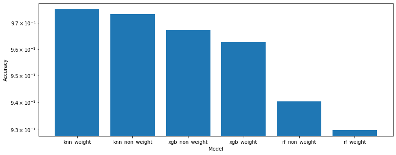

```python
#ทำการ plot bar chart เพื่อให้ง่ายต่อการอ่านค่าและเปรียบเทียบ โดยกำหนดให้ take log เพื่อใช้ในการแสดงค่า
plt.rcParams["figure.figsize"] = (13,5)
plt.bar(accuracy_df['Model'], accuracy_df['Accuracy'].round(4), log=True)
plt.ylabel('Accuracy')
plt.xlabel('Model');
```

**สรุปผล**: Model KNN ที่ใช้วิธี Term weighting ให้ accuracy สูงที่สุด